```python
using LinearAlgebra
using Polynomials
using Distributions
using SpecialMatrices
using Noise
using Plots
using CSV
using DataFrames
using Pkg
using Missings
```

# Numerically Stable Least Squares

### Derivation of the Least Squares equation

We want to minimize ${\Vert Y - X \beta \rVert}_2$. Consider $X$ to be the subspace spanned by its columns. This is a subspace of dimension $d$ in the larger space from which $Y$ originates.

We want the distance between $Y$ and $X \beta$ to be minimized. We know that the best approximation of $Y$ in the span of the columns of $X$ will be orthogonal to every column in $X$. Denote $P_X$ to be the orthogonal projection of $y$ onto subspace $X$. Let $u$ be another vector in col($X$). Then:

\begin{aligned} {\Vert y - P_X y \rVert}^2 &\leq {\Vert y - P_yy \rVert}^2 + {\Vert P_y y - u \rVert}^2 \\ &= {\Vert (y - P_X y) + (P_X y - u) \rVert}^2 \\ &= {\Vert y - u \Vert}^2 \end{aligned}

The first line follows because we are adding a value that is always non-negative. The second line follows by the Pythagorean Theorem (if $u$ and $v$ are orthogonal vectors in $V$, then ${\Vert u + v \rVert}^2 = {\Vert u \rVert}^2 + {\Vert v \rVert}^2$, and the third by algebra.

This implies (by Theorem 1 which we will also prove later) that $\langle X, Y - X \beta \rangle = 0$. It follows $\langle X, Y \rangle - \langle X, X \beta \rangle = 0$ by the property of inner products. Then $\langle X, Y \rangle = \langle X, X \rangle \beta$.

As a result, $\beta = \langle X, X \rangle^{-1}\langle X, Y \rangle$

If we let the inner product be the standard dot product, we have the familiar equation $\beta = (X^{T} X)^{-1} X^{T} Y$.

The Least Squares equations can also be derived using Calculus:

\begin{aligned} J(\theta) &=\frac{1}{2}(x \theta-y)^{\top}(x \theta-y) \\ &=\frac{1}{2}\left((x \theta)^{\top}-y^{\top}\right)(x \theta-y) \\ &=(x \theta)^{\top}(x \theta)-(x \theta)^{\top} y-y^{\top}(x \theta)+y^{\top} y \\ &=\theta^{\top} x^{\top} x \theta-(x \theta) \cdot y-y \cdot x \theta+y^{\top} y \\ &=\theta^{\top} x^{\top} x \theta-2(x \theta)^{\top} y+y^{\top} y \\ \end{aligned}

Now that we have a clean version of the cost function:

\begin{aligned} \frac{\partial J}{\partial \theta} &= \frac{\partial}{\partial \theta}\left(\theta^{\top} x^{\top} x \theta-2(x \theta)^{\top} y\right) \\ 0 &=2 x^{\top} x \theta-2 x^{\top} y \\ 0 &=x^{\top} x \theta-x^{\top} y \\ x^{\top} y &=x^{\top} x \theta \\ D &=\left(x^{\top} x\right)^{-1} x^{\top} y \end{aligned}

However, computing inverses is not numerically stable. To see this, consider data matrix X, a 100 by 15 Vandermonde matrix, and use this to approximate exp(sin(4x)) from 0 to 1 on 100 discretization points. The correct answer, computed using arbitrary precision arithmetic, is 2006.787453080206.

```python
vandermonde(t,n) = hcat( [t.^i for i = 0:n-1]... )

vandermonde(collect(0:0.25:1), 4) # Example Vandermonde Matrix
```

```python
a = 0; # Start
b = 1; # End

m = 100 # Number of discretization points
n = 15

h = 1/(m-1)
t = collect(a:h:b); # Generate 100 equidistant points between 0 and 1
```

```python
X = vandermonde(t, 15) # Compute a 100 by 15 Vandermonde Matrix
y = exp.(sin.(4 * t));
```

```python
# plot of y values
plot(t, y)
```

```python
X_t = transpose(X)

b = (inv(X_t * X)) * X_t * y
b[15]
```

```python
b = X \ y # Fitting least squares with library implementation
b[15]
```

## QR Decomposition

Given a matrix $A \in \mathbb{R}^{m \times n}$, we would like to compute $A = QR$, where $Q$ is an orthonormal matrix and $R$ is upper triangular.

We begin by revisiting the widely taught Gram-Schmidt Algorithm from elementary Linear Algebra. To form an orthonormal matrix that spans the columns of A, we can use the following iterative procedure:

Define the projector operator by $$\text{proj}_{u}(v) = \frac{\langle u,v \rangle}{\langle u,u\rangle}u$$

Then we have: \begin{aligned} u_1 &= v_1 \\ u_2 &= v_2 - \text{proj}_{u_1}(v_2) \\ u_3 &= v_3 - \text{proj}_{u_1}(v_3) - \text{proj}_{u_2}(v_3) \\ \ldots \\ u_k &= v_k - \sum_{j=1}^{k - 1}\text{proj}_{u_j}(v_k) \end{aligned}

Our orthonormal matrix Q can them be computed by normalizing the vectors $u_1 \ldots u_k$.

### Derivation of the Gram-Schmidt Process

**Theorem 1:** *Two vectors $u, v \in V$ are orthogonal if $\langle u, v \rangle = 0$.*

*Proof.* Recall the law of cosines: $c^2 = a^2 + b^2 - 2ab\cos\theta.$

\begin{aligned} &\|\vec{v}-\vec{u}\|^{2}=\|u\|^{2}+\|v\|^{2}-2\|u\|\|v\| \cos \theta \\ &\langle \vec{v}-\vec{u}\rangle \cdot \langle \vec{v}-\vec{u} \rangle=\|u\|^{2}+\|v\|^{2}-2\|u\|\|v\| \cos \theta \quad \text { since }\|x\|^{2}=x \cdot x \\ &\|v\|^{2}-2 \langle u, v\rangle +\|\vec{u}\|^{2}=\|u\|^{2}+\|v\|^{2}-2\|u\|\|v\| \cos \theta \\ &-2\langle u, v\rangle =-2\|u\|\|v\| \cos \theta \\ & \langle u, v\rangle = \|u\|\|v\| \cos \theta \\ \end{aligned}

Recall that the 0 vector is orthogonal to every other vector, and that if a vector is non-zero, then it's norm is positive. Thus, if $u$ and $v$ are non-zero, $\langle u, v \rangle = 0$ only when the cosine of their angle is 0, which we recall only occurs if the angle is 90 or 270 degrees.

*Projections and Inner products:*

Now suppose we want to find the projection of $a$ onto $x$, where $x$ is a unit vector. By the definition of $\cos \theta$, we have $\cos \theta = \frac{\text{Proj}_xa}{\Vert a \rVert}$ and $\text{Proj}_xa = \Vert a \rVert \cos \theta = \Vert a \rVert \Vert x \rVert \cos \theta = \langle a, x \rangle$, as desired. Thus we see there is a fundamental connection between projection and the inner product.

*Orthogonalization of Linearly Independent Vectors*:

Now that we have the fundamentals, let us consider the orthogonalization process itself. Firstly, a single vector $v_1$ can be made orthonormal by simply making it a unit vector. Now suppose we have a second, linearly independent vector $v_2$. Since $v_2$ is linearly independent, it means it is not simply a scalar multiple of $v_1$; in other words, it also travels in a direction different than $v_1$. Using this linear independence, we can break $v_2$ into two parts: one part that travels in the same direction as $v_1$, and one part that travels in a different direction.

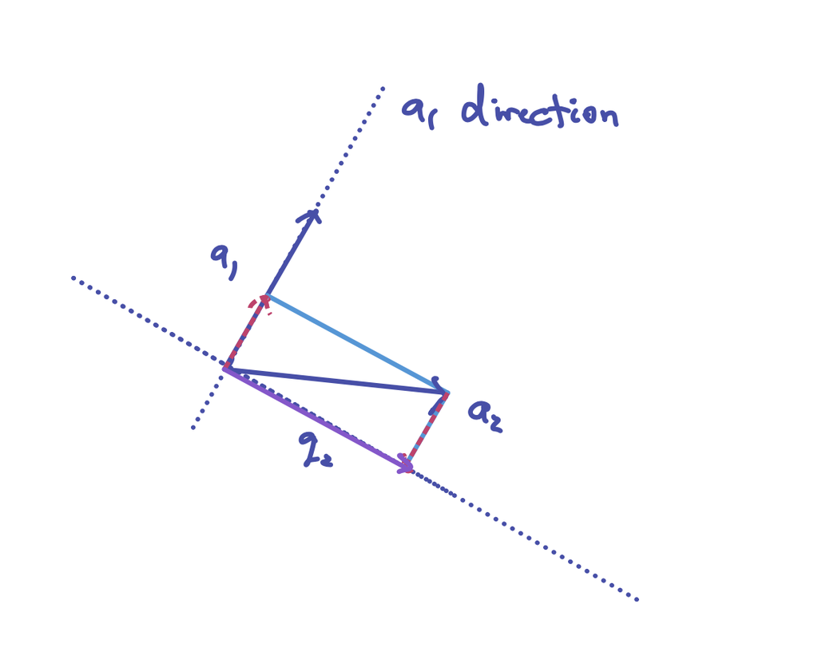

Here, $a_1$ is the vector in the first direction, and we have $a_2$, which is clearly linearly independent in $\mathbb{R}^2$ but not orthogonal. What we can do is take the projection of $a_2$ onto $v_1$. This produces the vector along $a_1$ up to the blue horizontal line, namely the red dotted line. We then subtract this from $a_2$, which is illustrated by taking $_a2$ and then the red dotted line. The output of this operation gives us $q_2.$ $q_2$ is now orthogonal to $a_1$. This is exactly the iterative process of Gram-Schmidt, with the addition of normalization to get orthonormal, rather than just orthogonal vectors.

### Gram-Schmidt Process in Code

```python
function classical_gram_schmidt(A)
    m, n = size(A)
    R = zeros(n, n)
    Q = zeros(m, n)
    for j in 1:n # Go over every column of A (note that Julia is 1-indexed)
        v_j = A[:, j] # Grab the jth column of A
        for i in 1:(j-1) # For vectors v_1 to v_{j-1}
            R[i, j] = dot(Q[:, i], v_j) # Scalar project a_j onto v_i, i \in {1...j-1}
            v_j = v_j - R[i, j] * Q[:, i] # Subtract the vector projection of i from a_j
        end
        R[j, j] = norm(v_j) # store norm of v_j
        Q[:, j] = v_j / R[j, j] # Normalize
    end
    return Q, R
end;
```

```python
A = [1 2; 2 3]
```

```python
Q,R = classical_gram_schmidt(A);
display(Q)

# Check that Q is orthogonal, up to numerical precision (~16 digits)
println(dot(Q[:,1], Q[:,2]))
```

```python
# Check that Q is orthonormal
norm(Q[:, 1])
```

```python
display(R) # Check R is upper triangular
display(Q * R) # Check A = QR
```

### Orthogonal Projectors

We can re-write the Gram-Schmidt process using the language of orthogonal projectors. This in particular will be important for the Householder QR approach, which we will discuss later.

Let $V$ be a vector space, and $U$ be a subspace of $V$. Then the orthogonal projector of $V$ onto $U$, denoted $P_{u}(v)$, can be constructed as follows:

$\forall v \in V$, $v = u + w$, $u \in U, w \in U^\bot$, where $U^\bot$ is the set of vectors in $V$ orthogonal to every vector in $U$.

Then $P_{u}(v) = u$.

Key properties of orthogonal projectors are:

1. $P_u(u) = u \quad \forall u \in U$
2. $P_u(w) = 0 \quad \forall w \in U^{\bot}$.
3. $\forall u \in U, \Vert v - P_u(v) \rVert \leq \Vert v - u \rVert$
4. $P^2 = P$

Proof of 1:

Since $u\in$ Range(P), $\exists v'$ s.t. P(v') = u. P(u) = P(Pv') = $P^2$(v') = P(v') = u.

In fact, (4) is a key property of projectors, and is sometimes used as the definition of general projectors, which contain oblique projectors in addition to orthogonal projectors. However, as we will see, seperating a vector space into two orthogonal subspaces is a key property of an orthogonal projector.

**Theorem: If $V$ is a finite dimensional inner product space and $P$ is a linear map with range P = U, a subspace of V and every vector in null(P) is orthogonal to every vector in range(P), then P is $P_u$.**

Proof. Since $P$ is a linear map, by rank-nullity on $P$, dimV = dim Null P + dim Range P. By assumption, Null P $\cap$ Range P = $\{0\}$.

Suppose $v \in$ Range P, $v \in$ Null P. $P(v) = v$ by 1. $P(v) = 0$ since $v \in$ nulll P. Thus $v = 0$.

Thus range P $\oplus$ nullP, and $U^\perp$ = (range $P)^\perp$ = null P. Let $v \in V$.

v = $u + w$, $u \in$ Range(P), $w\in$ Null(P). By definition, the $P_u(v) = u$.

P(v) = P(u) + P(w) by linearity.

P(u) = u by (1). P(w) = 0 by (2) Thus P(v) = u, and $\forall v \in V$, $P(v) = P_u(v)$ as desired.

## Householder QR

So far, all of the algorithms we have seen construct a orthonormal matrix via a series of triangular operations. In Householder QR, we construct a triangular matrix via a series of orthogonal matrices.

To give an example, we want to construct R = $Q_3 Q_2 Q_1 A$, a triangular matrix, via a series of unitary matrices.

A = \begin{pmatrix} X & X & X \\ X & X & X \\ X & X & X \\ X & X & X \end{pmatrix}

$Q_1 A$ = \begin{pmatrix} X & X & X \\ 0 & X & X \\ 0 & X & X \\ 0 & X & X \end{pmatrix}

$Q_2 Q_1 A$ = \begin{pmatrix} X & X & X \\ 0 & X & X \\ 0 & 0 & X \\ 0 & 0 & X \end{pmatrix}

$Q_3 Q_2 Q_1 A$ = \begin{pmatrix} X & X & X \\ 0 & X & X \\ 0 & 0 & X \\ 0 & 0 & 0 \end{pmatrix}

That is, we want to find linear transformation $F$ s.t. for the kth step of the algorithm, $\forall x \in \mathbb{C}^{m - k + 1}$ $$F x =\begin{pmatrix} \Vert x \rVert \\ 0 \\ \vdots \\ 0 \end{pmatrix} $$

Note that for the first step, $x \in \mathbb{C}^{m}$, and as we move on, we decrease the dimensionality of $x$ so that the output matrix is triangular.

Naturally, the question is how to construct these unitary matrices.

We have vector $x$, as shown in the picture. We want to reflect it across the Hyperplane $H$ such that it is equal to $\Vert x \rVert e_1$. To do this, construct the vector $\Vert x \rVert e_1 - x$. Recall that vector subtraction takes the first vector, in this case the line on the x axis from the origin to $\Vert x \rVert e_1$, then we place $-x$ on this vector, and then the output is the vector from the origin to point formed by the subtraction, i.e. the purple line.

Now that we have the purple line, we find the Hyperplane that is perpendicular to the purple vector. The hyperplane will always be the dimension of the space minus 1; in this it is just the line in green. Now if we project $x$ onto the subspace $H$, we'll get a vector on $H$. But if we move this distance twice, we'll be on the x-axis, exactly where we want to be.

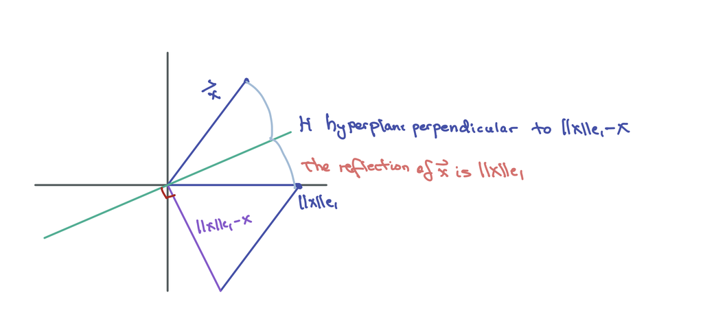

To do this numerically, we need several additional factors from project theory.

1. If $P$ is a projector, then so is $I - P$.
2. $I - P$ projects into null($P$).

For proofs of the two following statements, see Trefethan and Bau, Chapter 6.

Next, a rank-1 projector is $P_q = q q^*$, which projects $v$ into the direction of $q$. To see why, note that $q q^* v = q (q^* v)$ If $v$ is real, $(q^*v) = (q^\intercal v)$. This is a scalar, and when $q$ is a unit vector, is the scalar product of $v$ onto $q$. Then we multiply by $q$ to get the vector projection.

By (2), the complement is the rank $m-1$ orthogonal projector that eliminates direction q, a unit vector. $P_{\perp q} = I - q q^{*}$

To get $\Vert x \rVert e_1$, we will need $(I - 2 q q^{*})(v)$.

Thus, once we have computed F, we need to get the dimensions right, and thus $Q_1 = \begin{pmatrix} I & 0 \\ 0 & F\end{pmatrix}$

Let us demonstrate the computation of $Q_1$, before moving onto the full Householder algorithm.

```python
function householder_q1(A)
    x_1 = A[:, 1] # Get first column of A
    println("x_1: ", x_1)
    v_1 = norm(x_1) * [1.0; 0; 0] - x_1 # Computing ||x|| e_1 - x
    println("v_1: ", v_1)
    Q_1 = Matrix{Float64}(I, 3, 3) - (2 * v_1 * v_1') / dot(v_1, v_1);
    return Q_1 * A
end;
```

```python
A = [1.0 2 4; 2 3 7 ; 7 13 17]
```

```python
R = householder_q1(A);
```

```python
display(R)
```

```python
# Adapted from Matlab implementation, CS 6210 Fall 2019, copyright David Bindel
function householder_qr(A)
    m, n = size(A)
    Q = Matrix{Float64}(I, m, m)
    R = A

    for j in 1:n
        normx = norm(R[j:end, j])
        s = -sign(R[j, j])
        u1 = R[j, j] - s * normx
        w = R[j:end, j] / u1
        w[1] = 1
        tau = -s * u1 / normx

        R[j:end, :] = R[j:end, :] - (tau * w) * (transpose(w) * R[j: end, :])
        Q[:, j:end] = Q[:, j:end] - (Q[:,j:end]*w)*transpose(tau*w)
    end
    R = triu(R)
    return Q, R
end;
```

```python
A = [12.0 -51 4; 6 167 -68; -4 24 -41; 17 16 15; 18 394 1]
```

```python
Q,R = householder_qr(A);

Q * R
```

```python
println(dot(Q[:, 1], Q[:, 4]))
```

```python
display(R)
```

```python
norm(Q[:, 3])
```

## Examples of Unstable Algorithms

To begin our discussion of numerical stability, let us begin with one class of algorithms known to be particularly unstable: root-finding, which is particularly applicable in the computation of eigenvalues through the characteristic polynomial. To illustrate this instability, consider the following examples.

The Wilkinson's polynomial is defined as $$p(x)=\prod_{i=1}^{i=20}(x-i) = (x- 1) (x-2) \cdots (x-20)$$

Since $p(x)$ has a root at x = 20, the polynomial is 0 at $x=20$.

```python
function wilkinson(x)
    output = 1
    for i in 1:20
        output = output * (x - i)
    end
    return output
end


wilkinson(20)
```

We now also construct the polynomial using Julia's Polynomials library, which nicely prints out the full polynomial.

```python
wk = fromroots(collect(1:20))
```

```python
wk(20)
```

Now we decrease our wilkonson polynomial by $2^{-23}$ in the 19th degree:

```python
modifier = Polynomial([0,0,0,0,0,0,0,0,0,0,0,0,0,0,0,0,0,0,0,2^-23])
```

```python
modified_wk = wk - modifier
```

Now let us compute the value of the polynomial evaluated at 20, as well as its roots. We find that the roots of the polynomial are now pushed into the complex domain.

Also, this is an example of Theorem 4.15 in Axler, Linear Algebra done Right:

*If $p \in \mathbb{C}$ is a polynomial with real coefficients, and $\lambda \in \mathbb{C}$ is a zero of $p$, then so is $\overline{\lambda}$.*

```python
modified_wk(20)
```

```python
roots(modified_wk)
```

## The Theory of Conditioning and Stability

We can define the absolute condition number of a problem as follows: $ \hat{k}=\lim_{\delta \rightarrow 0} \sup _{\|\delta x\| \leqslant \delta} \frac{\|\delta f\|}{\|\delta \times\|}$.

If $f$ is differentiable, we have the Jacobian of partial derivatives. Then $\partial f \approx J(x) \delta x$, and $\hat{k}=\|J(x)\|$.

The relative condition number $k= \lim_{\delta \rightarrow 0} \sup_{\Vert \delta x \rVert \leq \delta} \frac{\Vert \delta f \rVert}{\Vert f(x) \rVert} \bigg/{\frac{\Vert \delta x \rVert}{\Vert x \rVert}} $

If $f$ is differentiable, $k=\frac{\|J(x)\|}{\|f(x)\| /\|x\|}$.

Let us now consider some examples.

1. Consider $f: x \rightarrow x / 2, x \in \mathbb{R}$. f is differentiable with $J(x)=f^{\prime}(x)=\frac{1}{2}$.

Thus $k=\frac{\frac{1}{2}}{\frac{x}{2} / x}=\frac{\frac{1}{2}}{\frac{1}{2}}=1$.

This is well-conditioned.

1. Consider $f:[x_1, x_2]^{T} \mapsto \mapsto x_{1}-x_{2}.$, using the $\infty$-norm for simplicity. $ J(x)=\left[\begin{array}{ll} \frac{\partial f}{\partial x_{1}} & \frac{\partial f}{\partial x_{2}} \end{array}\right]=\left[\begin{array}{ll} 1 & -1 \end{array}\right] $

$\|J(x)\|_{\infty}=2$ since $\|A\|_{\infty}=\max _{1 \leq i \varepsilon n} \sum_{j=1}^{n}\left|a_{i j}\right|$, where $i$ is the row of $A, j$ is the column.

Thus $k(x) = \frac{{\Vert J \rVert}_\infty}{\frac{\|x_1 - x_2\|}{\max \{x_1, x_2\}}}$

This problem is ill-conditionined if $x_1$ is approximately $x_2$, matching our intuition for cancellation error.

Consider the example below.

```python
x_1 = 1000000
x_2 = 1000000.0004

k = 2 / ((abs(x_1 - x_2)) / x_2)
print(k)

x_2 - x_1 # We see some error in this subtraction
```

```python
a_1 = 10
a_2 = 10.0004
print(a_2 - a_1) # The Error is of a much lower absolute magnitude than above.
```

### Condition of Matrix Vector Multiplication:

Let $A \in \mathbb{R}^{m \times n}$. We want to understand $k$ of $A x$ under perturbations of $x$.

$\begin{aligned} k &=\sup _{\delta x}\left(\frac{\|A(x+\delta x)-A x\|}{\|A x\|} \bigg/ \frac{\|\delta x\|}{\|x\|}\right) \\ &=\sup \frac{\|A \delta x\|}{\| x} \frac{\|x\|}{\|A x\|} \\ &=\|A\| \cdot \frac{\|x\|}{\|A x\|} \end{aligned}$

The last result follows from the properties of matrix norms. For more details, see Trefethan and Bau, Chapter 3.

Since $\|x\| \|A x\| \leq \|A^{-1}\|$, we have $\kappa \leq \|A\| \cdot\ \|A^{-1}\|)$

Under the ${\Vert \rVert}_2$ norm in particular, from the SVD, $\|A\|_{2}=\|U \Sigma V^{T}\|$ $=\left\|\sum\right\|$ since $U, V^{*}$ unitary.

Under the two-norm, this is equal to $\sigma_{1}$ the largest singular value. $$ \begin{aligned} A^{-1} &= (U \Sigma V^{T})^{-1} \\ &=V \Sigma^{-1} V^{T} \end{aligned} $$ $\left\|A^{-1}\right\|_{2}=\frac{1}{\sigma_{m}}$ the smallest singular value. As a result, $K(A) \leqslant \frac{\sigma_{1}}{\sigma_{m},}$

From this derivation, we see why $A^{-1}$ is unstable in general. If $A$ is close to being lineang dependent, then it will have small $\sigma_m$, and $\frac{1}{\sigma_m}$ will be large, resulting in an ill-conditioned problem.

Here is a concrete example of this problem.

```python
A = [1 1 1; 2 2.1 2.2; 3 3.01 3.02]
```

```python
x_1 = [1.7; 1.8; 1.9]
x_2 =  [1.71; 1.81; 1.91]

calc_1 = inv(A) * x_1
```

```python
calc_2 = inv(A) * x_2 # Under a very slight perturbation of x, we get an almost entirely different result
```

```python
println(norm(calc_2 - calc_1)) # On the order of 10 trillion
println(norm(x_2 - x_1)) # Change in norm of input is < 1
```

### Numerical Stability

Let our theoretical function $f: X \rightarrow Y$. An algorithm $\tilde{f}: X \rightarrow Y$ with some degree of error.

Absolute Error: $\|\tilde{f}(x)-f(x)\|$

Relative Error: $\frac{\|\tilde{f}(x)-f(x)\|}{\|f(x)\|}$

$\tilde{f}$ is accurate if $\forall x \in x, \frac{\|\tilde{f}(x)-f(x)\|}{\|f(x)\|}=o\left(\varepsilon_{\text {machine }}\right)$.

However, if $f$ is already ill-conditioned, this goal is very hard.

Thus, we can define stability as follows:

$\tilde{f}$ is stable if $\frac{\|\tilde{f}(x)-f(x)\|}{\|f(x)\|}=o\left(\varepsilon_{\text {machine }}\right)$ for some $\tilde{x}$ satisfying $\frac{\|\tilde{x}-x\|}{\|x\|}=o\left(e_{\text {machine }}\right)$

In the words of Trefethan and Bau, **"A stable algorithm gives nearly the right answer to nearly the right question."**

We can also define backwards stability, which is stronger, simpler, and relatively common along numerical linear algebra algorithms:

$\forall x \in X, \tilde f(x) = f(\bar x)$ for $\bar x$ satisfying $\frac{\Vert \bar x - x \rVert}{\Vert x \rVert}$.

In other words, **A backwards stable algorithm gives exactly the right answer to nearly the right question.**

## The Backwards Stability of Householder QR

We perform the following experiment to show the backwards stability of Householder QR, due to Trefethan and Bau. Note that Julia implements the QR decomposition using Householder reflectors.

Also note that triu creates an upper triangular matrix by setting elements below diagonal to 0.

```python
R = triu(rand(Uniform(0,1),50,50));
Q,X = qr(rand(Uniform(0,1),50,50));
A = Q * R;
Q2, R2 = qr(A);
```

In effect, we create a matrix A with known QR decomposion, and compare this to the QR decomposition of A as computed via Householder triangularization.

```python
norm(Q2 - Q)
```

```python
norm(A - Q2 * R2) / norm(A)
```

## Instability of Gram-Schmidt

We begin with a relatively normal looking matrix, and compute the quality of the orthogonality for the classical Gram-Schmidt and Householder procedures. Gram-Schmidt quickly becomes unstable because it is projecting $v_j$ onto all of the previous orthonormal vectors, thus causing substantial rounding error.

```python
function compute_dots(Q)
    m, n = size(Q)
     for i in 2:n
        print("iteration ", i, ": ", dot(Q[:, 1], Q[:, i]))
        print("\n")
    end
end;
```

```python
A = [1.0 0. 0.;0.001 0.0 -0.707; 0.001 -1 0.707]
```

```python
Q, R = classical_gram_schmidt(A);
display(Q)
compute_dots(Q)
```

```python
A = [1.0 0. 0.;0.001 0.0 -0.707; 0.001 -1 0.707]
Q,R = householder_qr(A);
display(Q)
compute_dots(Q)
```

```python
using SpecialMatrices
H = convert(Array{Float64}, Hilbert(10))
```

```python
Q,R = classical_gram_schmidt(H)
compute_dots(Q)
```

```python
H = convert(Array{Float64}, Hilbert(11))
Q,R = householder_qr(H)
compute_dots(Q)
```

```python
H = convert(Array{Float64}, Hilbert(11))
Q,R = qr(H);
compute_dots(Q)
```

Finally, to drive home the instability of the classical Gram-Schmidt algorithm, one that is always taught in elementary linear algebra, we show the result for dimension = 1024.

```python
H = convert(Array{Float64}, Hilbert(1024))
Q,R = classical_gram_schmidt(H)
dot(Q[:, 1], Q[:, 1024])
```

## Putting it all together: Numerically Stable Least Squares

The following derivation is from Wood (2006).

We know that for any matrix $A \in R^{m \times n}$ with $m \geq n$, the QR decomposition exists, where $Q$ is an orthogonal matrix, and $R$ is upper triangular. For Linear Regression, the design matrix $X$ satisfies this, so $X=Q R$. A second key fact about orthogonal matrices that we need is that $Q Q^{T} = I_{n}$.

\begin{align*} {\Vert y-X \beta \rVert}^{2}&=Q^{\top}{\|y-X \beta\|}^2 \\ &={\left\|Q^{\top} y-Q^{\top} Q R \beta\right\|}^2 \\ &=\left\|Q^{\top} y-R \beta\right\| \\ &= {\Vert \left[\begin{array}{l}f \\ r\end{array}\right] - \left[\begin{array}{l}R \\ 0\end{array}\right] \rVert}^2 \end{align*}

The first line follows since the norm of an orthonormal matrix is 1.

The third line follows since $Q^{T} Q = I_n$.

In the fourth line, we wrote $Q^{T} y = \left[\begin{array}{l}f \\ r\end{array}\right]$, where $f \in R^{p}$, and $f \in R^{n - p}$.

Now recall for any $v$, $\|v\|^{2}=\sum_{i} v_{i}^{2}$, so if $v=\left[\begin{array}{c}\vec{u} \\ \vec{\omega}\end{array}\right], \sum_{i} u_{i}^{2}+\sum_{i} w_{i}^{2}=\|u\|^{2}+\|w\|^{2}$.

\begin{align*} {\Vert y-X \beta \rVert}^{2}&={\Vert \left[\begin{array}{l}f \\ r\end{array}\right] - \left[\begin{array}{l}R \\ 0\end{array}\right] \rVert}^2 \\ &=\|f-R\|^{2}+\|r\|^{2} \end{align*}

To minimize $\|y-x\| \|^{2}$, note that $\beta$ is independent of $r=n-p$, so the mimimum is achieved when $\|f-R\|^{2}=0$

$\|f-R \beta\|^{2}=0 \Rightarrow \beta=R^{-1} f$

This derivation implies we can compute $\hat{\beta}$ for X and y as follows:

1. Decompose $X = Q \left[\begin{array}{l}R \\ 0\end{array}\right]$. If $X \in \mathbb{R}^{m \times n}$, with $m \geq n$, then $Q \in \mathbb{R}^{m \times m}, R \in \mathbb{R}^{m \times n}$. However, if you consider the triangular matrix with more rows than columns, clearly the last rows are zero. Thus, we only need the $n$ columns of $R$.
2. Compute $f = Q^{T} y$. As the derivation states, we only need the first p values of $f$.
3. Return $b = R^{-1}f$. However, this is equivalent to $Rb = f.$ However, $R$ is triangular, so this computation can be easily done by back substitution. Let $b_n = f_n$, then back substitute into the the $2 \times 2$ system, and so forth.

```python
function linear_regression(X, y)
    _, p = size(X)
    Q, R = householder_qr(X)
#     Q, R = householder_qr(X)
    R = R[1:p, :] # Take the first p rows of R
    f = (transpose(Q) * y)[1:p]
    betas = back_substitute(R, f)
    return betas
end


function back_substitute(U, y)
    n, _ = size(U)
    x = zeros(n)
    for i in n:-1:1
        x[i] = y[i]
        for j in (i+1): n
            x[i] = x[i] - U[i, j] * x[j]
        end
        x[i] = x[i] / U[i, i]
    end
    return x
end;
```

Here the example that we saw at the beginning. Now we try with a more stable algorithm.

```python
a = 0; # Start
b = 1; # End

m = 100 # Number of discretization points
n = 15

h = 1/(m-1)
t = collect(a:h:b); # Generate 100 equidistant points between 0 and 1
```

```python
vandermonde(t,n) = hcat( [t.^i for i = 0:n-1]... )

X = vandermonde(t, 15) # Compute a 100 by 15 Vandermonde Matrix
y = exp.(sin.(4 * t));
```

```python
betas = linear_regression(X, y)
betas[15]
```